# Who voted for Trump? Analysis with Rpart

2017-01-13 17:06:09 UYT

In a few days we will be witnessing the inauguration of President-Elect Donald Trump, whose victory over Hillary Clinton came as a shock for most people. I’m not much into politics (and it is not even my country!) but this result really caught my attention, so I wanted to dig a little about the reasons why he won.

I’ve been studying Machine Learning for a while now, and a couple of months ago I discovered the *awesome* `tidiverse` world (I can’t believe the way I used to do things :$), so I thought this was a great topic to test my skills. In addition to that, English is not my mother tongue so in this first post I am facing major challenges! If you see something improvable, not clear o plainly wrong, please leave a comment or [mention me on Twitter](https://twitter.com/intent/tweet?user_id=114258616) :)

What I do here is estimate a Classification Tree (CART) to find an association between the winner in the county and its socio-demographic characteristics.

# The data

I recently joined Kaggle, and [Joel Wilson](https://www.kaggle.com/joelwilson) gathered data about *2016 US Election Results* by county and *County Quick Facts* from the *US Census Bureau*. [This is the data](https://www.kaggle.com/joelwilson/2012-2016-presidential-elections) I use to run my analysis.

I start by loading the data and merging it. No mystery here, except I merge it using `dplyr` (yay!).

```r
library(dplyr)

pop <- tbl_df(read.csv('county_facts.csv'))
results <- tbl_df(read.csv('US_County_Level_Presidential_Results_12-16.csv'))

votes2 <- pop %>%
  left_join(results, by = c("fips" = "combined_fips"))
```

It is a clean dataset, but I need to do some modifications for the analysis:

- There is no election data for the state of Alaska so I remove those counties.
- Replace the old ID (`X`) with a new one (`ID`).
- Delete non relevant variables.
- Rename variables to make them interpretable.

All of this taking advantage of the `dplyr` of course.

```r
votes <- votes %>%
  filter(state_abbr != "AK") %>%
  mutate(ID = rank(X)) %>%
  select(-X, -POP010210, -PST040210, -NES010213, -WTN220207) %>%
  rename(age18minus = AGE295214, age5minus =    AGE135214, age65plus = AGE775214,
    american_indian = RHI325214, asian = RHI425214, asian_Firms = SBO215207,
    black = RHI225214, black_firms = SBO315207, building_permits = BPS030214,
    density = POP060210, edu_batchelors = EDU685213, edu_highschool = EDU635213,
    firms_num = SBO001207, foreign = POP645213, hisp_latin = RHI725214,
    hispanic_firms = SBO415207, home_owners_rate = HSG445213, households = HSD410213,
    housing_Units = HSG010214, housing_units_multistruct = HSG096213, income = INC910213,
    land_area = LND110210, living_same_house_12m = POP715213, manuf_ship = MAN450207,
    Med_house_income = INC110213, Med_val_own_occup =   HSG495213, native_haw = RHI525214,
    native_firms = SBO115207, nonenglish = POP815213, pacific_isl_firms = SBO515207,
    pers_per_household = HSD310213, pop_change = PST120214, pop2014 = PST045214,
    poverty = PVY020213, priv_nofarm_employ = BZA110213, priv_nonfarm_employ_change = BZA115213,
    priv_nonfarm_estab = BZA010213, retail_sales = RTN130207, retail_sales_percap = RTN131207,
    sales_accomod_food = AFN120207, sex_f = SEX255214, travel_time_commute = LFE305213,
    two_races_plus = RHI625214, veterans = VET605213, white = RHI125214, white_alone = RHI825214,
    women_firms = SBO015207,
    Trump = per_gop_2016, Clinton = per_dem_2016, Romney = per_gop_2012, Obama = per_dem_2012)
```

Most of these variables are measured as a percentage of people in the county with that characteristic (e.g. `edu_batchelors` and `black`), or the total amount in the county (e.g. `land_area` and `firms_num`).

Note that there is a `white` variable and a `white_alone` variable. This is because there are 2 separate facts gathered here.

- `white` refers to *race*: *people having origins in any of the original peoples of Europe, the Middle East, or North Africa*. If a person declares `white` among other races, is classified as `two_races_plus` and not as `white`.
- `white_alone` refers to white *race* people who also reported *not Hispanic or Latino origin*.

For further references on any other variable you can [go to the Census Bureau’s site](https://www.census.gov/quickfacts/).

# Building the Response Variable

I create the variable I want to predict: `pref_cand_T`. It takes the value `1` if `Trump` has a greater percentage of votes than `Clinton` in the county, and `0` otherwise. Note that it is not necessary that one of them has more than 50% of the votes, it only has to have more votes than the other.

```r
votes <- votes %>% mutate(pref_cand_T = factor(ifelse(Trump > Clinton, 1, 0)))

votes %>% summarize(Trump       = sum(pref_cand_T == 1),
                    Clinton     = n() - Trump,
                    Trump_per   = mean(pref_cand_T == 1),
                    Clinton_per = 1 - Trump_per)
```

```
## # A tibble: 1 × 4
##   Trump Clinton Trump_per Clinton_per
##   <int>   <int>     <dbl>       <dbl>
## 1  2624     488 0.8431877   0.1568123
```

*Trump* got more votes than *Clinton* in 2624 counties opposing the 488 other counties were *Clinton* got more votes (remember we are talking about counties and not Electoral College votes). The proportion is 84% for *Trump* and 16% for *Clinton*.

# Some visualization about race and origin

I explore briefly some counties’ characteristics about race and origin by visualizing them. Besides my interest, I also want to put to use my brand new `ggplot` skills!

I generate a plot for the mean of each characteristic across all counties, which is the mean of the proportion of people with each characteristic in all counties (simple mean, without considering the population of the county).

```r
library(tidyr)
library(ggplot2)

total <- votes %>%
  summarize(
    white       = mean(white),
    white_alone = mean(white_alone),
    black       = mean(black),
    asian       = mean(asian),
    hisp_latin  = mean(hisp_latin),
    foreign     = mean(foreign)) %>%
  gather(variable, value) %>%
  ggplot() +
  geom_bar(aes(x = variable, y = value),
           stat = 'identity', width = .7, fill = "#C9C9C9") +
  geom_vline(xintercept = c(4.5, 5.5), alpha = 0.2 ) +
  scale_x_discrete(limits = c("white", "white_alone", "black", "asian", "hisp_latin", "foreign")) +
  labs(title = "Proportion in counties",
       subtitle = "(simple mean of counties proportion, without considering county population)") +
  theme_bw() +
  theme(axis.title.x = element_blank(), axis.title.y = element_blank(),
        axis.text.x = element_blank(), axis.line = element_line(colour = "grey"),
        panel.grid.major = element_blank(), panel.border = element_blank())
```

Something beautiful about `tidyverse` is the way that you can build up the solution. The first part is simply `dplyr` plus `tidyr::gather`, necessary to manipulate the input for the `ggplot`. The rest is the `ggplot` layer by layer.

It seems like a lot of code for a simple plot, but trust me: once you get the hang of `ggplot`, it is magic! The only fear is that you’ll want to customize *everything*! (An that’s why I have so much code…)

Then I generate the same plot by winner.

```r
library(reshape2)

by_candidate <- votes %>%
  group_by(pref_cand_T) %>%
  summarize(
    white       = mean(white),
    white_alone = mean(white_alone),
    black       = mean(black),
    asian       = mean(asian),
    hisp_latin  = mean(hisp_latin),
    foreign     = mean(foreign)) %>%
    melt(id.vars = 'pref_cand_T') %>%
  ggplot() +
    geom_bar(aes(x = variable, y = value, fill = pref_cand_T),
             stat = 'identity', position = 'dodge') +
    geom_vline(xintercept = c(4.5, 5.5), alpha = 0.2 ) +
    scale_fill_manual(values = alpha(c("blue", "red")),
                      breaks = c("0", "1"), labels = c("Clinton", "Trump")) +
    labs(
 #     title = "Proportion among candidates",
 #     subtitle = "(Simple mean of counties proportion without considering county population)",
      fill = "winner") +
    theme_bw() +
    theme(axis.title.x = element_blank(), axis.title.y = element_blank(),
          axis.line = element_line(colour = "grey"), legend.position = "bottom",
          panel.grid.major = element_blank(), panel.border = element_blank())
```

Same as before, but I use `reshape2::melt` instead of `tidyr::gather` to generate the `ggplot` input, now that I have 2 groups.

Next I plot both. I use the `gridExtra` package to display both plots together. (And yes, it was a lot of learning this past few months!).

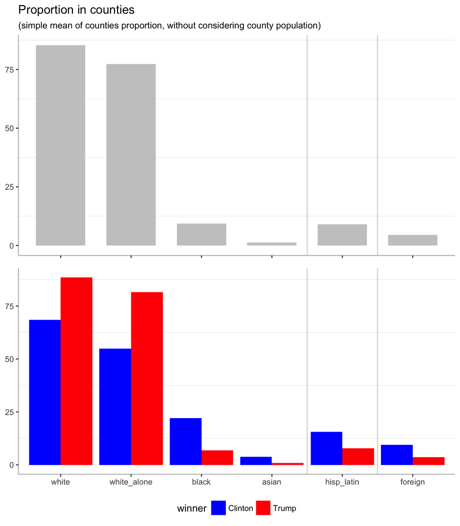

```r
library(gridExtra)

grid.arrange(total, by_candidate, nrow = 2)
```

Among races, the mean of white people is higher for the counties where Trump won than the rest, and for the counties where Clinton won, the mean of black and asian people is higher. Clinton also won in counties with higher mean of Hispanic or Latin origin people, and foreign-born population. In a future post I will be doing some more digging into this variables to find out more.

# The Classification Tree

As a standard practice, I split the data into `train` and `test` samples. I use 70% of the counties for training and the rest for testing. Since I am dealing with unbalanced data, I use the `createDataPartition` function in the `caret` package that conserves the proportion of classes across all samples.

```r
library(caret)

perc_train <- 0.7
set.seed(3333)

trainIndex <- createDataPartition(y = votes$pref_cand_T, p = perc_train,
                                  list = FALSE, times = 1)

train <- votes %>% subset(ID %in% trainIndex)
test <-  votes %>% setdiff(train)
```

I estimate the tree using `rpart`, excluding variables non relevant for modelling, and those used to build the response variable.

```r
library(rpart)

pref_cand_rpart <- rpart(pref_cand_T ~ .,
                         data = train[, -c(1:24, 70)],
                         control = rpart.control(xval = 10, cp = 0.0001))
```

This algorithm grows a tree from a root that has all the observations, splitting binarily to reduce the impurity of its nodes, until some stopping rule is met. I set this rules with the `rpart.control`:

- `minsplit = 20`: use the default, the minimum in a node to attempt a split.
- `minbucket = 7`: use the default, the minimum in any terminal node.
- `cp = 0.0001`: the factor of decreasing lack of fit for a split to be attempted.

Now it’s time to prune the tree. To do this, I will keep the split if it meets some criteria about the balance between the impurity reduction (*cost*) and the increase of size (*complexity*). This is the `cp`.

I am pruning the tree following the 1-SE rule, according to which we choose the simplest model with accuracy similar to the best model.

```r
library(tibble)
cp <- as_tibble(pref_cand_rpart$cptable) %>%
  filter(xerror <= min(xerror) + xstd) %>%
  filter(xerror == max(xerror)) %>%
  select(CP) %>%
  unlist()

winner_rpart <- prune(pref_cand_rpart, cp = cp)
```

`dplyr` manipulates dataframes, so I use the `tibble::as_tibble` function to convert the `pref_cand_rpart$cptable` table to a tibble, and then select the `cp`.

And here I have the tree! (If you know some other way to plot nicer trees, please comment!)

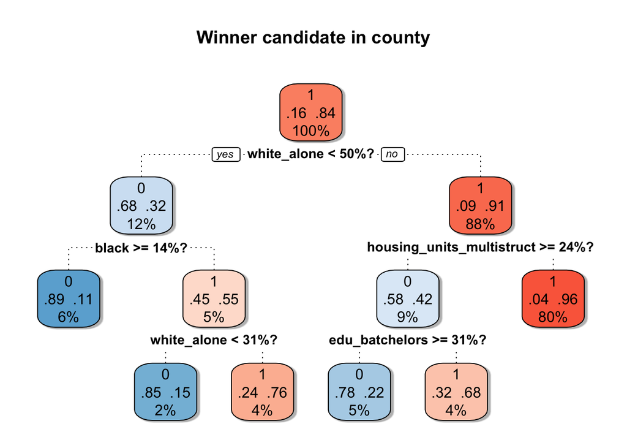

```r
library(rpart.plot)

rpart.plot(winner_rpart, main = "Winner candidate in county",
           extra = 104, split.suffix = "%?", branch = 1,
           fallen.leaves = FALSE, box.palette = "BuRd",
           branch.lty = 3, split.cex = .9,
           shadow.col = "gray", shadow.offset = 0.2)
```

Apparently race is one of the most important characteristic determining the winner candidate. 3 over the 5 splits include race (we will know more about this when we check the Variable Importance later on).

# Performance Evaluation

## Missclassification Error

Now I evaluate the fit. One way to do it is by calculating the missclassification error over the test sample, simply by computing the percentage of times that the the classifier wrong.

```r
test <- test %>%
  mutate(pred = predict(winner_rpart, type = "class", test),
         pred_prob_T = predict(winner_rpart, type = "prob", test)[,2],
         error = ifelse(pred != pref_cand_T, 1, 0))

test %>% summarize(missc_error = mean(error))
```

```
## # A tibble: 1 × 1
##   missc_error
##         <dbl>
## 1  0.07824223
```

Prior to this post I would use this measure without taking into account how unbalanced the data was. But I’ve doing some research and it became clear that in this case I could not treat this performance measure without further considerations.

Let’s suppose I have a model that predict for all cases Trump as the winner. It would have a missclassification error of 15%, not so bad! But it is definitely not a great model: it would be 100% accurate for predicting counties where Trump won, but it would be wrong for *all* of the counties where Clinton won. This is known as the *Accuracy Paradox*, and that is why we need some alternatives to measure how good is this tree in predicting the county’s winner.

## Kappa statistic

One good thing to do in any case (balanced the data or not) is to take a look at the confusion matrix. This is the input for many performance measures as shown next.

```r
test %>%
  select(pred, pref_cand_T) %>%
  table() %>%
  confusionMatrix()
```

```
## Confusion Matrix and Statistics
##
##     pref_cand_T
## pred   0   1
##    0  87  14
##    1  59 773
##
##                Accuracy : 0.9218
##                  95% CI : (0.9026, 0.9382)
##     No Information Rate : 0.8435
##     P-Value [Acc > NIR] : 6.196e-13
##
##                   Kappa : 0.6611
##  Mcnemar's Test P-Value : 2.607e-07
##
##             Sensitivity : 0.59589
##             Specificity : 0.98221
##          Pos Pred Value : 0.86139
##          Neg Pred Value : 0.92909
##              Prevalence : 0.15648
##          Detection Rate : 0.09325
##    Detection Prevalence : 0.10825
##       Balanced Accuracy : 0.78905
##
##        'Positive' Class : 0
##
```

Just looking into this matrix we can have some clues on how well is the classifier for each class. Particularly I want to look closer at the `Kappa` measure, because it specifically consider the unbalance between classes.

`Kappa` measures the accuracy of the classifier corrected by the probability of agreement by chance. There is not much consensus on the magnitude of `Kappa` to consider it low or high, but it can be interpreted as how separate it is the obtained result from chance. In this case, the *expected accuracy* (the one that occurs by chance) is 77% and the perfect accuracy is always 100%. There is a gap of 23%, and this classifier closes this gap by 66% of it (15% of improvement!). The higher the `Kappa` is, the better. Some sustain that a value of `Kappa` larger than 60% means a good agreement, so we are OK!

## ROC Curve and AUROC

To complement the performance evaluation, I check the `ROC curve`. It plots the *True Positive Rate* against the *False Positive Rate* across many different thresholds of predicted probability. Since we are evaluating a tree, there is a limited amount of thresholds since I only have 6 final nodes.

This measure is great for classification analysis, and is particularly useful here because it is not affected by unbalanced classes. Luckily I came across this great `ggplot2` extension, `plotROC` so I have a pretty nice plot!

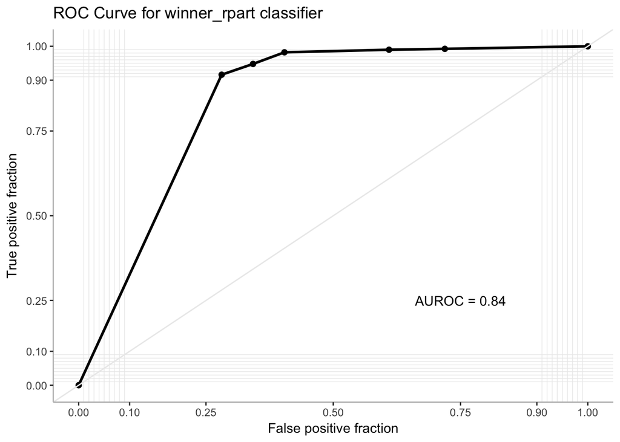

```r
library(plotROC)

roc <- test %>%
  select(pref_cand_T, pred_prob_T) %>%
  mutate(pref_cand_T = as.numeric(pref_cand_T) - 1,
         pref_cand_T.str = c("Clinton", "Trump")[pref_cand_T + 1]) %>%
  ggplot(aes(d = pref_cand_T, m = pred_prob_T)) +
  geom_roc(labels = FALSE)

roc +
style_roc(theme = theme_bw) +
theme(panel.grid.major = element_blank(), panel.border = element_blank(),
      axis.line = element_line(colour = "grey")) +
ggtitle("ROC Curve for winner_rpart classifier") +
annotate("text", x = .75, y = .25,
         label = paste("AUROC =", round(calc_auc(roc)$AUC, 2)))
```

The `AUROC` (*A*rea *U*nder the *ROC* curve) computes the probability that the classifier ranks higher a positive instance than a negative one. (If you want to get deeper into this, I highly recommend [this Tom Fawcett paper](http://tomfawcett.info/papers/ROC-PRL.pdf))

# Warning about Classification Trees instability

When you use this kind of Machine Learning algorithm you should be aware that small changes in the data can generate different trees. Next there is a second tree generated using the same parameters than before, but changing the seed.

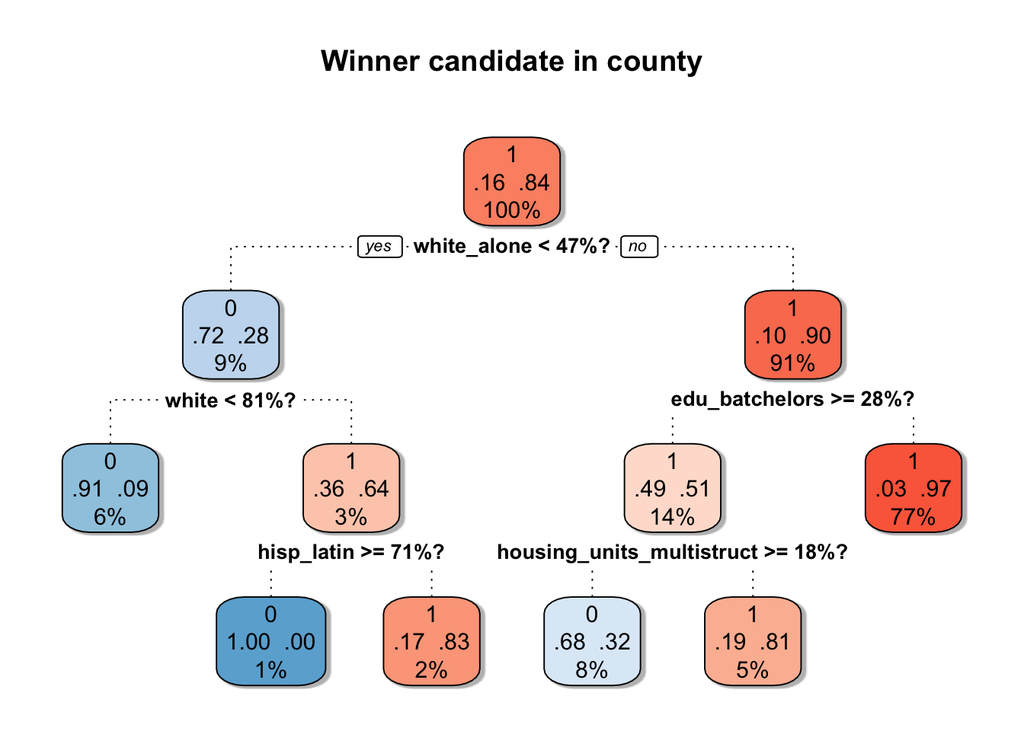

```r
set.seed(4444)

trainIndex_2 <- createDataPartition(y = votes$pref_cand_T, p = perc_train,
                                    list = FALSE, times = 1)

train_2 <- votes %>% subset(ID %in% trainIndex_2)
test_2 <-  votes %>% setdiff(train_2)

winner_rpart_2 <- rpart(pref_cand_T ~ .,
                         data = train_2[, -c(1:24, 70)],
                         control = rpart.control(xval = 10, cp = cp))

rpart.plot(winner_rpart_2, main = "Winner candidate in county",
           extra = 104, split.suffix = "%?", branch = 1,
           fallen.leaves = FALSE, box.palette = "BuRd",
           branch.lty = 3, split.cex = .9,
           shadow.col = "gray", shadow.offset = 0.2)
```

Although it is not completely different, it changes.

You can fight this using some ensemble method such as *Bagging*, *Random Forest* or *Boosting*, but as I wanted to be able to interpret the results, this other methods are not as visual as this one.

Since this algorithm is very sensitive to the `train` and `test` splitting, I’m interested in having an estimation of the *accuracy* for this kind of specification of the tree. This is the Cross Validation error.

## k-fold Cross Validation for model accuracy estimation

This was a non that straight forward thing for me to do. I wanted the `caret` package to calculate the K-fold Cross Validation accuracy estimation, but apparently most people use it to find the parameter `cp` at the same time. I just wanted to estimate the error associated with an already specified model.

Finally I found the way, specifying `tuneGrid = expand.grid(cp = cp)`.

```r
tc <- trainControl("cv", number = 30)
rpart.grid <- expand.grid(cp = cp)
train.rpart <- train(pref_cand_T ~ .,
                     data = votes[,-c(1:24, 70)], method = "rpart",
                     trControl = tc,  tuneGrid = rpart.grid)
train.rpart$results
```

```
##          cp  Accuracy     Kappa AccuracySD   KappaSD
## 1 0.0380117 0.9206584 0.6806005 0.02740935 0.1158789
```

The `Kappa` statistic is now 0.68 (it was 0.66 for the winner_rpart), with a 0.12 Standard Deviation. Again: good results!

# Variable Importance

One last thing to check is the Variable Importance. CART is a *greedy* algorithm, meaning that it chooses the best split at each node without any consideration of the potential benefit of choosing another split on the overall tree performance. This way we can end up with a tree without some variables that are apparently relevant.

The *Variable Importance* in `rpart` is calculated not only taking into account the goodness of the split for variables that are actually in the tree, but also for the `surrogate` variables (the variables used in case the main variable is missing). We can see next that there are many more variables than in the tree.

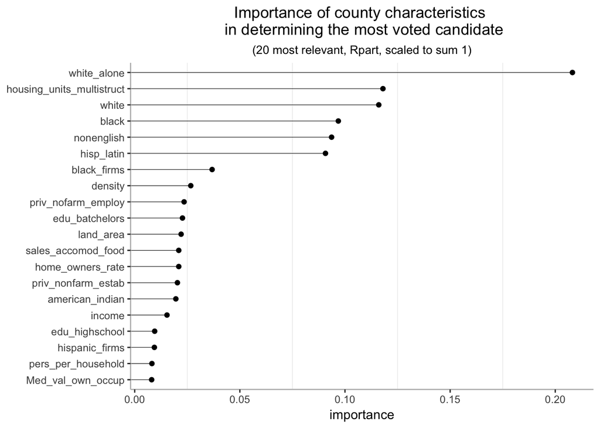

```r
winner_rpart$variable.importance %>%
  data_frame(variable = names(.), importance = .) %>%
  mutate(importance = importance / sum(importance)) %>%
  top_n(20) %>%
  ggplot(aes(x = importance,
             y = reorder(variable, importance))) +
  geom_point() +
  labs(title = "Importance of county characteristics \n in determining the most voted candidate",
       subtitle = "(20 most relevant, Rpart, scaled to sum 1)") +
  theme_bw() +
  theme(axis.title.y = element_blank(),
        plot.title = element_text(hjust = 0.5),
        plot.subtitle = element_text(hjust = 0.5),
        axis.line = element_line(colour = "grey"),
        panel.grid.major = element_blank(), panel.border = element_blank()) +
  geom_segment(aes(x = -Inf, y = reorder(variable, importance),
                   xend = importance, yend = reorder(variable, importance)),
               size = 0.2)
```